# **Genepar1: Pain scores & Medication Use**

Vivek Verma

2021-07-30

# 1 **Selection of Pain Phenotype**

Numerous pain phenotypes were collected in Quebec Pain Registry (QPR). Following criteria was applied to select a pain phenotype for the analysis downstream:

1. It should capture the pain severity,
2. it should be collected through a valid questionnaire,
3. the same question should have been administered at all the follow-up visits,
4. it should have less than 10% missing data at baseline, and,
5. it should be a continuous variable with $\sim \text{Normal}(\mu, \sigma)$

**Brief Pain Inventory (BPI)** met the criteria (1) and (2) but not (3) and (4). Hence the next best option, the following components of BPI that best meets all the above mentioned criteria were investigated:

- PQ00_YOUR_PAIN_Q1: pain right now
- PQ00_YOUR_PAIN_Q2: average pain in past 7 days
- PQ00_YOUR_PAIN_Q3: worst pain in past 7 days

**PQ00_YOUR_PAIN_Q2 i.e. *“In the past 7 days, how would you rate your low-back pain on average?”*** was most strongly associated with the overall BPI scores, hence, was chosen for downstream analyses.

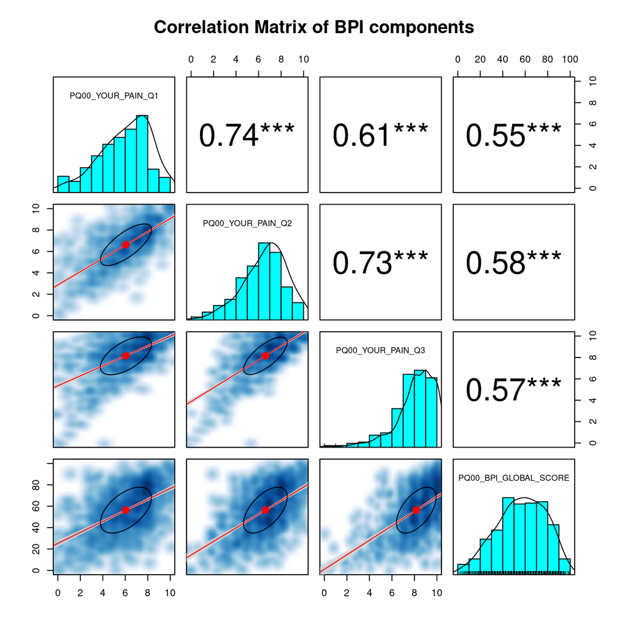

```r
# load data:
df1 <- haven::read_sas("/mnt/nfs/backup/data/quebec_pain_registry/outdir/requete.sas7bdat",
               "/mnt/nfs/backup/data/quebec_pain_registry/outdir/formats.sas7bcat")
# select relevant variables:
df1 <- df1 %>% select(PQ00_YOUR_PAIN_Q1,PQ00_YOUR_PAIN_Q2,
                      PQ00_YOUR_PAIN_Q3,PQ00_BPI_GLOBAL_SCORE)
# correlation plots
pairs.panels(df1,method = "pearson",stars=T, lm = T, ci = T,
             jiggle = T, smoother = T, density = T, ellipses = T,
             main = "Correlation Matrix of BPI components")
```

# 2 **Data Summary**

## 2.1 Data structure

```r
# load data:
df <- readRDS("./genepar/GENEPAR1.RDS")
# select relevant variables:
df <- df[,c(1:3,7,9:12,78:82)]; glimpse(df)
```

```
## Rows: 982
## Columns: 13
## $ ID             <chr> "000715", "002163", "002666", "002716", "003768", "0041…
## $ DIAGNOSIS      <fct> Lower Back Pain, Neuropathic Pain, Neuropathic Pain, Ne…
## $ SEX            <fct> Female, Male, Male, Female, Male, Male, Male, Female, F…
## $ CLINIC         <fct> CHUM, MUHC, MUHC, HDL, HDL, CHUM, CHUS, CHUM, HDL, CHUM…
## $ AGE            <dbl> 52, 25, 60, 52, 36, 60, NA, 45, 37, 36, 52, 40, 55, 47,…
## $ BMI            <dbl> 19, 25, 28, 27, 29, 27, 23, 22, 29, 20, 32, 24, 27, 20,…
## $ PAIN_BASELINE  <dbl> 7, 8, 6, 6, 8, 6, NA, 2, 8, 2, 4, 8, 7, 8, 5, 7, 5, 5, …
## $ PAIN_FOLLOW_UP <dbl> 9, 7, 4, 3, 3, 1, 9, 2, 7, 1, 4, 8, 8, 8, 1, 10, 6, 3, …
## $ ACETAMINOPHEN  <fct> 1, 0, 1, 0, 0, 1, NA, NA, 0, 1, 0, 1, 1, 0, NA, 0, 0, 0…
## $ GABA_ANALOGS   <fct> 0, 0, 0, 1, 0, 1, NA, NA, 0, 1, 1, 1, 1, 0, NA, 0, 0, 0…
## $ OPIOIDS        <fct> 1, 0, 0, 0, 1, 1, NA, NA, 1, 0, 1, 1, 0, 1, NA, 0, 0, 1…
## $ NSAIDS         <fct> 0, 0, 1, 0, 0, 1, NA, NA, 1, 0, 1, 1, 1, 0, NA, 0, 0, 0…
## $ OTHER          <fct> 1, 1, 0, 0, 0, 0, NA, NA, 1, 0, 1, 1, 0, 1, NA, 1, 1, 1…
```

## 2.2 Summary of continuous variables:

```r
dt <- summarize(df, type = "numeric", group = "DIAGNOSIS")
dt <- as.data.frame(dt)
row.names(dt) <- NULL
names(dt)[1] <- "Variable"
dt <- dt[,-c(3,6,9,11,13,15)]
dt$DIAGNOSIS[dt$DIAGNOSIS == "Lower Back Pain"] <- "LBP"
dt$DIAGNOSIS[dt$DIAGNOSIS == "Neuropathic Pain"] <- "NP"
kbl(dt, caption = "Summary of all continuous variables") %>%
  kable_classic("hover", html_font = "Cambria", full_width = T)
```

Summary of all continuous variables

| Variable | DIAGNOSIS | N | Missing | Mean | SD | Min | Median | Max | p.value |
| --- | --- | --- | --- | --- | --- | --- | --- | --- | --- |
| AGE | LBP | 500 | 9 | 54.9 | 10.6 | 23 | 56 | 75 | <0.001 |
|  | NP | 470 | 3 | 51.6 | 11.4 | 18 | 52 | 77 |  |
| BMI | LBP | 509 | 0 | 28.1 | 6.3 | 11 | 27 | 51 | 0.300 |
|  | NP | 473 | 0 | 27.7 | 6.4 | 13 | 27 | 60 |  |
| PAIN_BASELINE | LBP | 500 | 9 | 6.7 | 1.9 | 0 | 7 | 10 | 0.300 |
|  | NP | 470 | 3 | 6.5 | 1.9 | 0 | 7 | 10 |  |
| PAIN_FOLLOW_UP | LBP | 501 | 8 | 5.7 | 2.3 | 0 | 6 | 10 | 0.700 |
|  | NP | 465 | 8 | 5.8 | 2.4 | 0 | 6 | 10 |  |

### 2.2.1 Correlation plots:

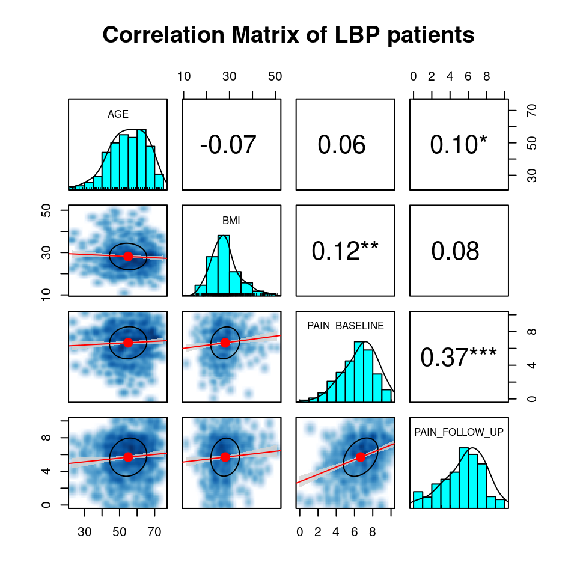

```r
# correlation plots:
df1 <- df[df$DIAGNOSIS == "Lower Back Pain",c(5:8)]
pairs.panels(df1,
             method = "pearson",stars=T, lm = T, ci = T, jiggle = T, smoother = T, density = T, ellipses = T,
             main = "Correlation Matrix of LBP patients")
```

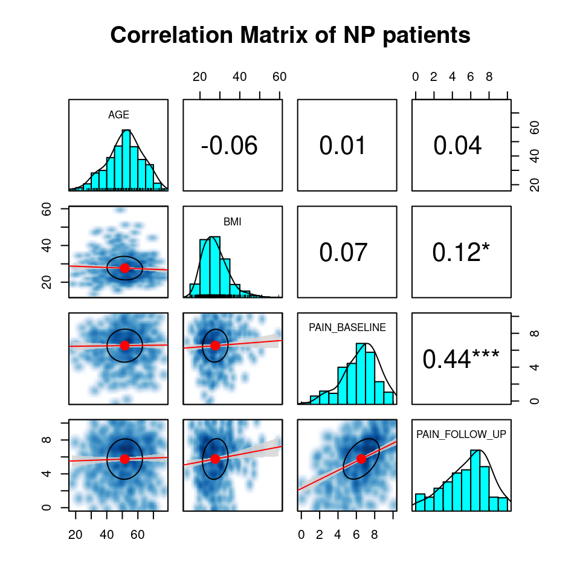

```r
df1 <- df[df$DIAGNOSIS == "Neuropathic Pain",c(5:8)]
pairs.panels(df1,
             method = "pearson",stars=T, lm = T, ci = T, jiggle = T, smoother = T, density = T, ellipses = T,
             main = "Correlation Matrix of NP patients")
```

## 2.3 Summary of categorical variables:

```r
dt <- summarize(df[,-4], type = "factor", group = "DIAGNOSIS")
dt <- as.data.frame(dt)
dt <- dt[,-c(3,6,9)]
names(dt) <- c("Variable","Level","N_LBP","%_LBP","N_NP","%_NP","p.value")
kbl(dt, caption = "Summary of all categorical variables") %>%
  kable_classic("hover", html_font = "Cambria", full_width = T)
```

Summary of all categorical variables

| Variable | Level | N_LBP | %_LBP | N_NP | %_NP | p.value |
| --- | --- | --- | --- | --- | --- | --- |
| SEX | Female | 276 | 54.2 | 308 | 65.1 | 0.001 |
|  | Male | 233 | 45.8 | 165 | 34.9 |  |
| ACETAMINOPHEN | 0 | 200 | 39.3 | 180 | 38.1 | 0.192 |
|  | 1 | 223 | 43.8 | 165 | 34.9 |  |
|  | <Missing> | 86 | 16.9 | 128 | 27.1 |  |
| GABA_ANALOGS | 0 | 234 | 46.0 | 192 | 40.6 | 0.942 |
|  | 1 | 189 | 37.1 | 153 | 32.3 |  |
|  | <Missing> | 86 | 16.9 | 128 | 27.1 |  |
| OPIOIDS | 0 | 224 | 44.0 | 201 | 42.5 | 0.145 |
|  | 1 | 199 | 39.1 | 144 | 30.4 |  |
|  | <Missing> | 86 | 16.9 | 128 | 27.1 |  |
| NSAIDS | 0 | 230 | 45.2 | 227 | 48.0 | 0.001 |
|  | 1 | 193 | 37.9 | 118 | 24.9 |  |
|  | <Missing> | 86 | 16.9 | 128 | 27.1 |  |
| OTHER | 0 | 250 | 49.1 | 179 | 37.8 | 0.049 |
|  | 1 | 173 | 34.0 | 166 | 35.1 |  |
|  | <Missing> | 86 | 16.9 | 128 | 27.1 |  |

## 2.4 Change in pain over time:

Irrespective of the diagnosis or sex, pain scores tend to decrease over the time.

```r
dfl <- readRDS("./GENEPAR1_long.RDS")
df.summary <- dfl %>%
  group_by(DIAGNOSIS,TIME,SEX) %>%
  dplyr::summarise(
    Pain = mean(PAIN_NRS, na.rm = T),
    n = n(),
    sd = sd(PAIN_NRS, na.rm = T),
    se = sd/sqrt(n))
df.summary  %>%
  kbl(caption = "Summary of Pain") %>%
  kable_classic("hover", html_font = "Cambria", full_width = T)
```

Summary of Pain

| DIAGNOSIS | TIME | SEX | Pain | n | sd | se |
| --- | --- | --- | --- | --- | --- | --- |
| Lower Back Pain | BASELINE | Female | 6.8 | 633 | 1.8 | 0.07 |
| Lower Back Pain | BASELINE | Male | 6.6 | 537 | 1.9 | 0.08 |
| Lower Back Pain | FOLLOW_UP | Female | 5.7 | 633 | 2.3 | 0.09 |
| Lower Back Pain | FOLLOW_UP | Male | 5.7 | 537 | 2.2 | 0.10 |
| Neuropathic Pain | BASELINE | Female | 6.8 | 666 | 1.8 | 0.07 |
| Neuropathic Pain | BASELINE | Male | 6.7 | 334 | 2.0 | 0.11 |
| Neuropathic Pain | FOLLOW_UP | Female | 5.9 | 666 | 2.3 | 0.09 |
| Neuropathic Pain | FOLLOW_UP | Male | 6.0 | 334 | 2.2 | 0.12 |

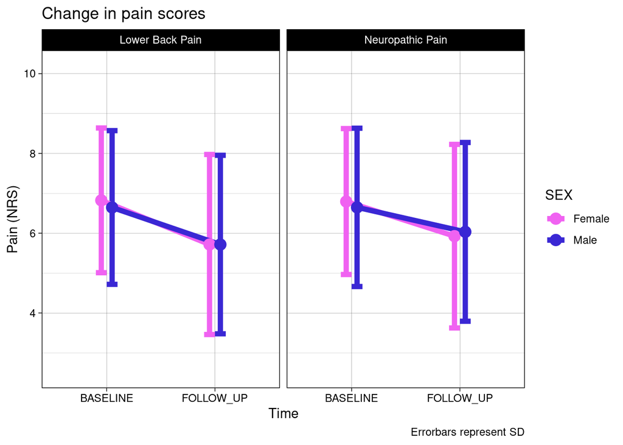

```r
# plot
pd <- position_dodge(0.2)
  ggplot(df.summary, aes(x=TIME, y=Pain, colour=SEX, group=SEX)) +
    geom_errorbar(aes(ymin=Pain-sd, ymax=Pain+sd, colour=SEX),
                  width=0.2, position=pd, lwd = 2) +
    geom_line(aes(colour=SEX),position=pd, lwd = 2) +
    geom_point(aes(fill=SEX),position=pd, size=4, shape=21) +
  scale_fill_manual(values = c("#F062F1","#3A27D4"))  +
  scale_color_manual(values = c("#F062F1","#3A27D4")) +
    labs(title = "Change in pain scores",
         x = "Time",
         y = "Pain (NRS)",
         caption = "Errorbars represent SD") +
    ylim(2.5,10.2) +
    facet_wrap(~DIAGNOSIS) + theme_linedraw()
```

# 3 **Statistical Modeling**

## 3.1 Generating composite pain phenotypes:

In addition to the baseline and follow-up pain NRS scores, following two phenotypes were generated:

1. PAIN_CHANGE: (numeric) Pain at follow-up - Pain at baseline
2. PAIN_IMPROVED: (logical) TRUE if PAIN_CHANGE < 0, FALSE if PAIN_CHANGE ≥ 0

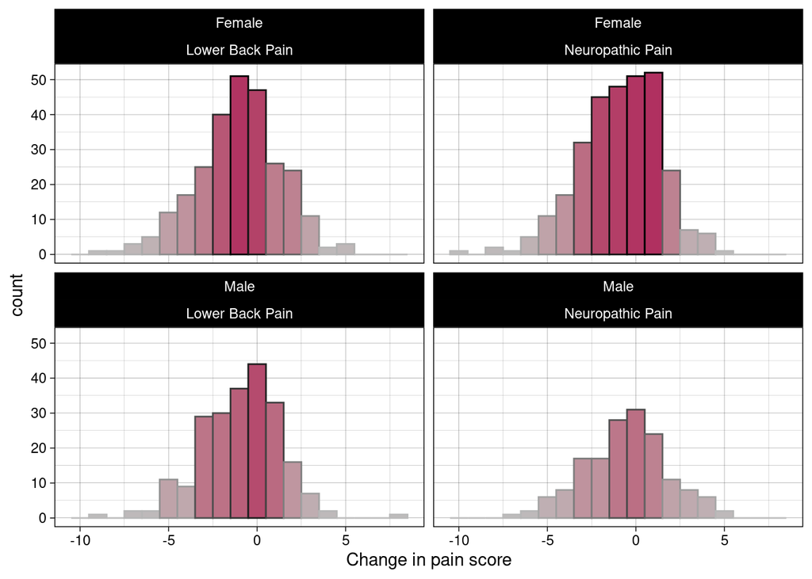

```r
df$PAIN_CHANGE <- df$PAIN_FOLLOW_UP - df$PAIN_BASELINE
ggplot(df, aes(x = PAIN_CHANGE)) +
             geom_histogram(aes_string(fill = "..count..",
                                       color = "..count.."),
                            binwidth = 1) +
             scale_fill_gradient(low="gray",high="maroon") +
             scale_color_gradient(low="gray",high="black") +
             xlab("Change in pain score") + theme_linedraw() +
             theme(legend.position = "none")+facet_wrap(~SEX + DIAGNOSIS)
```

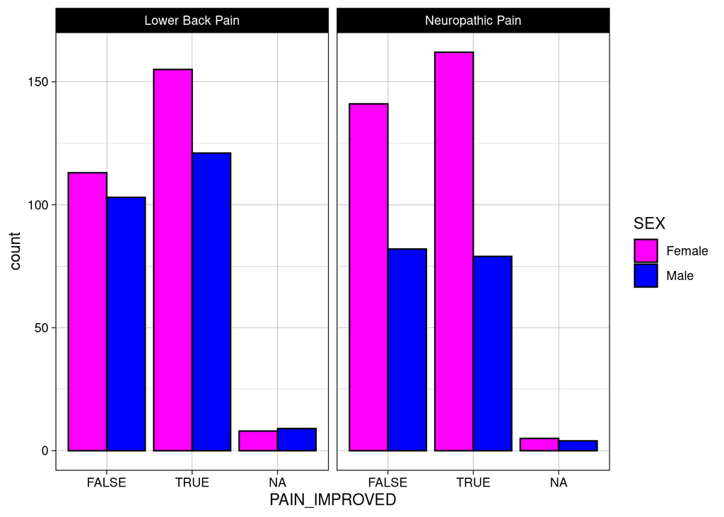

```r
df$PAIN_IMPROVED <- as.logical(ifelse(df$PAIN_CHANGE < 0, 1, 0))
ggplot(df, aes(x=PAIN_IMPROVED,fill=SEX)) +
        geom_bar(position = "dodge",color = "black", lwd = 0.5) +
        #xlab("PAIN IMPROVED") +
        scale_fill_manual(values = c("magenta","blue")) +
  facet_wrap(~DIAGNOSIS) + theme_linedraw()
```

```r
local({
  .Table <- xtabs(~PAIN_IMPROVED+DIAGNOSIS, data=df)
  cat("\nFrequency table: Pain improved vs Diagnosis\n")
  print(.Table)
  .Test <- chisq.test(.Table, correct=T)
  print(.Test)
})
```

```
##
## Frequency table: Pain improved vs Diagnosis
##              DIAGNOSIS
## PAIN_IMPROVED Lower Back Pain Neuropathic Pain
##         FALSE             216              223
##         TRUE              276              241
##
##  Pearson's Chi-squared test with Yates' continuity correction
##
## data:  .Table
## X-squared = 1, df = 1, p-value = 0.2
```

```r
local({
  .Table <- xtabs(~PAIN_IMPROVED+SEX, data=df)
  cat("\nFrequency table: Pain improved vs sex\n")
  print(.Table)
  .Test <- chisq.test(.Table, correct=T)
  print(.Test)
})
```

```
##
## Frequency table: Pain improved vs sex
##              SEX
## PAIN_IMPROVED Female Male
##         FALSE    254  185
##         TRUE     317  200
##
##  Pearson's Chi-squared test with Yates' continuity correction
##
## data:  .Table
## X-squared = 1, df = 1, p-value = 0.3
```

## 3.2 Welch Two Sample t-test

```r
dt <- data.frame(matrix(nrow = 5, ncol = 4))
names(dt) <- c("Drug","Control","Treatment","Pval")
dt$Drug[1:5] <- names(df)[9:13]
for (i in 1:5) {
  dt[i,2] <- t.test(as.formula(paste("PAIN_CHANGE ~ ", dt[i,1])), data = df)[["estimate"]][["mean in group 0"]]
  dt[i,3] <- t.test(as.formula(paste("PAIN_CHANGE ~ ", dt[i,1])), data = df)[["estimate"]][["mean in group 1"]]
  dt[i,4] <- t.test(as.formula(paste("PAIN_CHANGE ~ ", dt[i,1])), data = df)[["p.value"]]
}
kbl(dt, caption = "T-test of Pain change w.r.t. drug intake") %>%
  kable_classic("hover", html_font = "Cambria", full_width = T)
```

T-test of Pain change w.r.t. drug intake

| Drug | Control | Treatment | Pval |
| --- | --- | --- | --- |
| ACETAMINOPHEN | -0.87 | -1.02 | 0.38 |
| GABA_ANALOGS | -0.87 | -1.04 | 0.31 |
| OPIOIDS | -1.02 | -0.86 | 0.35 |
| NSAIDS | -0.89 | -1.03 | 0.42 |
| OTHER | -1.01 | -0.87 | 0.42 |

```r
for (i in 1:5) {
  dt[i,2] <- t.test(as.formula(paste("PAIN_CHANGE ~ ", dt[i,1])), data = df[df$DIAGNOSIS == "Lower Back Pain",])[["estimate"]][["mean in group 0"]]
  dt[i,3] <- t.test(as.formula(paste("PAIN_CHANGE ~ ", dt[i,1])), data = df[df$DIAGNOSIS == "Lower Back Pain",])[["estimate"]][["mean in group 1"]]
  dt[i,4] <- t.test(as.formula(paste("PAIN_CHANGE ~ ", dt[i,1])), data = df[df$DIAGNOSIS == "Lower Back Pain",])[["p.value"]]
}
kbl(dt, caption = "T-test of Pain change w.r.t. drug intake in LBP") %>%
  kable_classic("hover", html_font = "Cambria", full_width = T)
```

T-test of Pain change w.r.t. drug intake in LBP

| Drug | Control | Treatment | Pval |
| --- | --- | --- | --- |
| ACETAMINOPHEN | -1.10 | -0.96 | 0.55 |
| GABA_ANALOGS | -0.87 | -1.21 | 0.14 |
| OPIOIDS | -1.05 | -1.00 | 0.84 |
| NSAIDS | -0.86 | -1.22 | 0.13 |
| OTHER | -1.09 | -0.93 | 0.49 |

```r
for (i in 1:5) {
  dt[i,2] <- t.test(as.formula(paste("PAIN_CHANGE ~ ", dt[i,1])), data = df[df$DIAGNOSIS == "Neuropathic Pain",])[["estimate"]][["mean in group 0"]]
  dt[i,3] <- t.test(as.formula(paste("PAIN_CHANGE ~ ", dt[i,1])), data = df[df$DIAGNOSIS == "Neuropathic Pain",])[["estimate"]][["mean in group 1"]]
  dt[i,4] <- t.test(as.formula(paste("PAIN_CHANGE ~ ", dt[i,1])), data = df[df$DIAGNOSIS == "Neuropathic Pain",])[["p.value"]]
}
kbl(dt, caption = "T-test of Pain change w.r.t. drug intake in NP") %>%
  kable_classic("hover", html_font = "Cambria", full_width = T)
```

T-test of Pain change w.r.t. drug intake in NP

| Drug | Control | Treatment | Pval |
| --- | --- | --- | --- |
| ACETAMINOPHEN | -0.62 | -1.11 | 0.06 |
| GABA_ANALOGS | -0.87 | -0.83 | 0.90 |
| OPIOIDS | -0.99 | -0.66 | 0.20 |
| NSAIDS | -0.92 | -0.73 | 0.47 |
| OTHER | -0.89 | -0.81 | 0.75 |

## 3.3 Lower Back Pain models

### 3.3.1 Dependent variable: Pain change

**PAIN_CHANGE ~ DRUG + AGE + SEX + BMI + (1 | CLINIC)**

```r
dt <- df %>% dplyr::filter(DIAGNOSIS == "Lower Back Pain")
m1ac <- lmer(PAIN_CHANGE ~ AGE + SEX + BMI + (1 | CLINIC) + ACETAMINOPHEN,
            data = dt)
m1gb <- lmer(PAIN_CHANGE ~ GABA_ANALOGS + AGE + SEX + BMI + (1 | CLINIC),
            data = dt)
m1op <- lmer(PAIN_CHANGE ~ OPIOIDS + AGE + SEX + BMI + (1 | CLINIC),
            data = dt)
m1ns <- lmer(PAIN_CHANGE ~ NSAIDS + AGE + SEX + BMI + (1 | CLINIC),
            data = dt)
export_summs(m1ac, m1gb, m1op, m1ns, scale = TRUE,
             error_format = "[{conf.low}, {conf.high}]")
```

|  | Model 1 | Model 2 | Model 3 | Model 4 |
| --- | --- | --- | --- | --- |
| (Intercept) | -1.12 *** | -0.91 *** | -1.08 *** | -0.91 *** |
|  | [-1.52, -0.72] | [-1.27, -0.54] | [-1.45, -0.71] | [-1.27, -0.54] |
| AGE | 0.07 | 0.09 | 0.09 | 0.08 |
|  | [-0.16, 0.31] | [-0.14, 0.32] | [-0.14, 0.32] | [-0.15, 0.31] |
| SEX | 0.08 | 0.09 | 0.07 | 0.09 |
|  | [-0.38, 0.54] | [-0.37, 0.55] | [-0.39, 0.53] | [-0.37, 0.55] |
| BMI | 0.07 | 0.07 | 0.06 | 0.07 |
|  | [-0.16, 0.30] | [-0.16, 0.30] | [-0.17, 0.29] | [-0.16, 0.30] |
| ACETAMINOPHEN | 0.12 |  |  |  |
|  | [-0.35, 0.59] |  |  |  |
| GABA_ANALOGS |  | -0.35 |  |  |
|  |  | [-0.81, 0.11] |  |  |
| OPIOIDS |  |  | 0.05 |  |
|  |  |  | [-0.41, 0.52] |  |
| NSAIDS |  |  |  | -0.35 |
|  |  |  |  | [-0.81, 0.11] |
| N | 417 | 417 | 417 | 417 |
| N (CLINIC) | 5 | 5 | 5 | 5 |
| AIC | 1925.24 | 1923.25 | 1925.46 | 1923.24 |
| BIC | 1953.47 | 1951.48 | 1953.69 | 1951.47 |
| R2 (fixed) | 0.00 | 0.01 | 0.00 | 0.01 |
| R2 (total) | 0.00 | 0.01 | 0.00 | 0.01 |
| All continuous predictors are mean-centered and scaled by 1 standard deviation. *** p < 0.001; ** p < 0.01; * p < 0.05. |  |  |  |  |

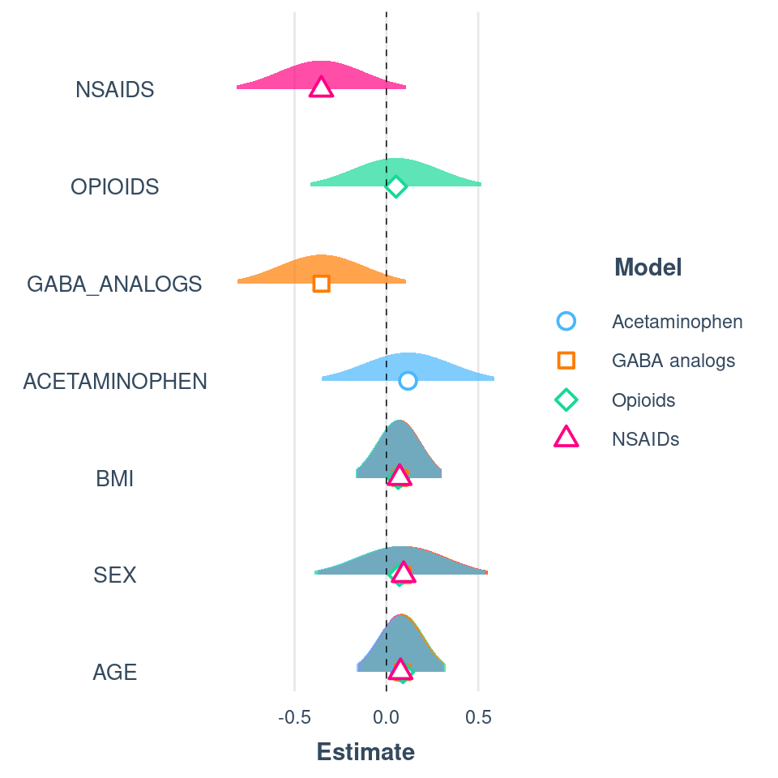

```r
plot_summs(m1ac, m1gb, m1op, m1ns, scale = T, plot.distributions = T,
           model.names = c("Acetaminophen","GABA analogs",
                           "Opioids","NSAIDs"))
```

### 3.3.2 Dependent variable: Pain at follow-up (corrected for baseline pain)

**PAIN_FOLLOW_UP ~ DRUG + AGE + SEX + BMI + PAIN_BASELINE + (1 | CLINIC)**

```r
m1ac <- lmer(PAIN_FOLLOW_UP ~ AGE + SEX + BMI + (1 | CLINIC) + PAIN_BASELINE + ACETAMINOPHEN,
            data = dt)
m1gb <- lmer(PAIN_FOLLOW_UP ~ GABA_ANALOGS + AGE + SEX + BMI + (1 | CLINIC) + PAIN_BASELINE,
            data = dt)
m1op <- lmer(PAIN_FOLLOW_UP ~ OPIOIDS + AGE + SEX + BMI + (1 | CLINIC) + PAIN_BASELINE,
            data = dt)
m1ns <- lmer(PAIN_FOLLOW_UP ~ NSAIDS + AGE + SEX + BMI + (1 | CLINIC) + PAIN_BASELINE,
            data = dt)
export_summs(m1ac, m1gb, m1op, m1ns, scale = TRUE,
             error_format = "[{conf.low}, {conf.high}]")
```

|  | Model 1 | Model 2 | Model 3 | Model 4 |
| --- | --- | --- | --- | --- |
| (Intercept) | 5.59 *** | 5.83 *** | 5.59 *** | 5.85 *** |
|  | [5.23, 5.95] | [5.51, 6.16] | [5.26, 5.91] | [5.52, 6.18] |
| AGE | 0.14 | 0.16 | 0.17 | 0.15 |
|  | [-0.07, 0.35] | [-0.05, 0.36] | [-0.03, 0.38] | [-0.06, 0.35] |
| SEX | -0.09 | -0.08 | -0.12 | -0.08 |
|  | [-0.50, 0.32] | [-0.49, 0.33] | [-0.54, 0.29] | [-0.49, 0.34] |
| BMI | 0.19 | 0.19 | 0.18 | 0.19 |
|  | [-0.02, 0.40] | [-0.01, 0.40] | [-0.03, 0.39] | [-0.01, 0.40] |
| PAIN_BASELINE | 0.80 *** | 0.80 *** | 0.79 *** | 0.80 *** |
|  | [0.59, 1.00] | [0.60, 1.01] | [0.58, 1.00] | [0.59, 1.01] |
| ACETAMINOPHEN | 0.18 |  |  |  |
|  | [-0.24, 0.60] |  |  |  |
| GABA_ANALOGS |  | -0.34 |  |  |
|  |  | [-0.75, 0.07] |  |  |
| OPIOIDS |  |  | 0.24 |  |
|  |  |  | [-0.17, 0.66] |  |
| NSAIDS |  |  |  | -0.37 |
|  |  |  |  | [-0.78, 0.04] |
| N | 417 | 417 | 417 | 417 |
| N (CLINIC) | 5 | 5 | 5 | 5 |
| AIC | 1835.88 | 1834.03 | 1835.32 | 1833.53 |
| BIC | 1868.15 | 1866.29 | 1867.58 | 1865.79 |
| R2 (fixed) | 0.14 | 0.15 | 0.14 | 0.15 |
| R2 (total) | 0.14 | 0.15 | 0.14 | 0.15 |
| All continuous predictors are mean-centered and scaled by 1 standard deviation. *** p < 0.001; ** p < 0.01; * p < 0.05. |  |  |  |  |

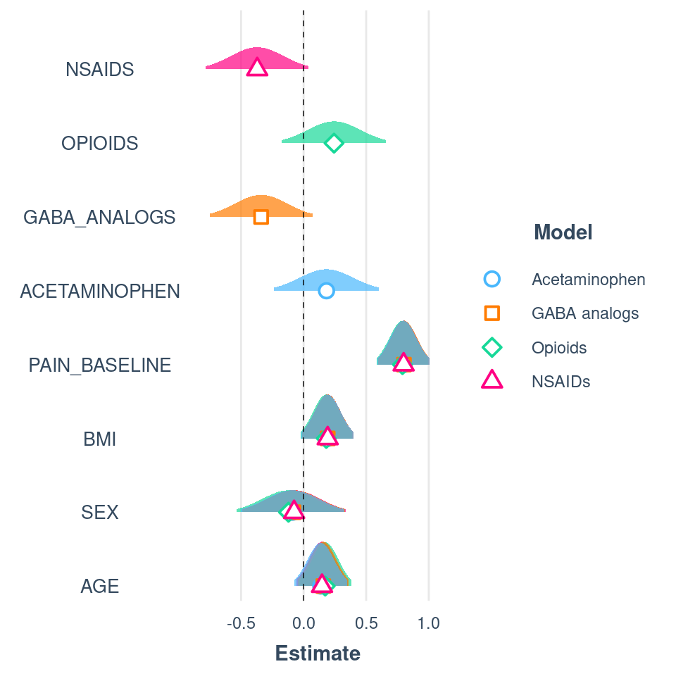

```r
plot_summs(m1ac, m1gb, m1op, m1ns, scale = T, plot.distributions = T,
           model.names = c("Acetaminophen","GABA analogs",
                           "Opioids","NSAIDs"))
```

### 3.3.3 Dependent variable: Pain improved

**PAIN_IMPROVED ~ DRUG + AGE + SEX + BMI + (1 | CLINIC)**

```r
m1ac <- glmer(PAIN_IMPROVED ~ AGE + SEX + BMI + (1 | CLINIC) + ACETAMINOPHEN,
            family = binomial, data = dt)
m1gb <- glmer(PAIN_IMPROVED ~ GABA_ANALOGS + AGE + SEX + BMI + (1 | CLINIC),
            family = binomial, data = dt)
m1op <- glmer(PAIN_IMPROVED ~ OPIOIDS + AGE + SEX + BMI + (1 | CLINIC),
            family = binomial, data = dt)
m1ns <- glmer(PAIN_IMPROVED ~ NSAIDS + AGE + SEX + BMI + (1 | CLINIC),
            family = binomial, data = dt)
export_summs(m1ac, m1gb, m1op, m1ns, scale = TRUE,
             error_format = "[{conf.low}, {conf.high}]")
```

|  | Model 1 | Model 2 | Model 3 | Model 4 |
| --- | --- | --- | --- | --- |
| (Intercept) | 0.32 | 0.30 | 0.31 | 0.22 |
|  | [-0.03, 0.66] | [-0.02, 0.61] | [-0.01, 0.62] | [-0.09, 0.53] |
| AGE | -0.14 | -0.14 | -0.14 | -0.14 |
|  | [-0.34, 0.06] | [-0.34, 0.06] | [-0.34, 0.06] | [-0.33, 0.06] |
| SEX | -0.13 | -0.13 | -0.13 | -0.14 |
|  | [-0.52, 0.26] | [-0.52, 0.26] | [-0.52, 0.27] | [-0.53, 0.25] |
| BMI | -0.00 | -0.00 | -0.00 | -0.01 |
|  | [-0.20, 0.19] | [-0.20, 0.19] | [-0.20, 0.19] | [-0.20, 0.19] |
| ACETAMINOPHEN | -0.04 |  |  |  |
|  | [-0.44, 0.36] |  |  |  |
| GABA_ANALOGS |  | 0.00 |  |  |
|  |  | [-0.39, 0.39] |  |  |
| OPIOIDS |  |  | -0.02 |  |
|  |  |  | [-0.42, 0.37] |  |
| NSAIDS |  |  |  | 0.18 |
|  |  |  |  | [-0.21, 0.57] |
| N | 417 | 417 | 417 | 417 |
| N (CLINIC) | 5 | 5 | 5 | 5 |
| AIC | 581.89 | 581.92 | 581.90 | 581.09 |
| BIC | 606.09 | 606.12 | 606.10 | 605.28 |
| R2 (fixed) | 0.01 | 0.01 | 0.01 | 0.01 |
| R2 (total) | 0.01 | 0.01 | 0.01 | 0.01 |
| All continuous predictors are mean-centered and scaled by 1 standard deviation. *** p < 0.001; ** p < 0.01; * p < 0.05. |  |  |  |  |

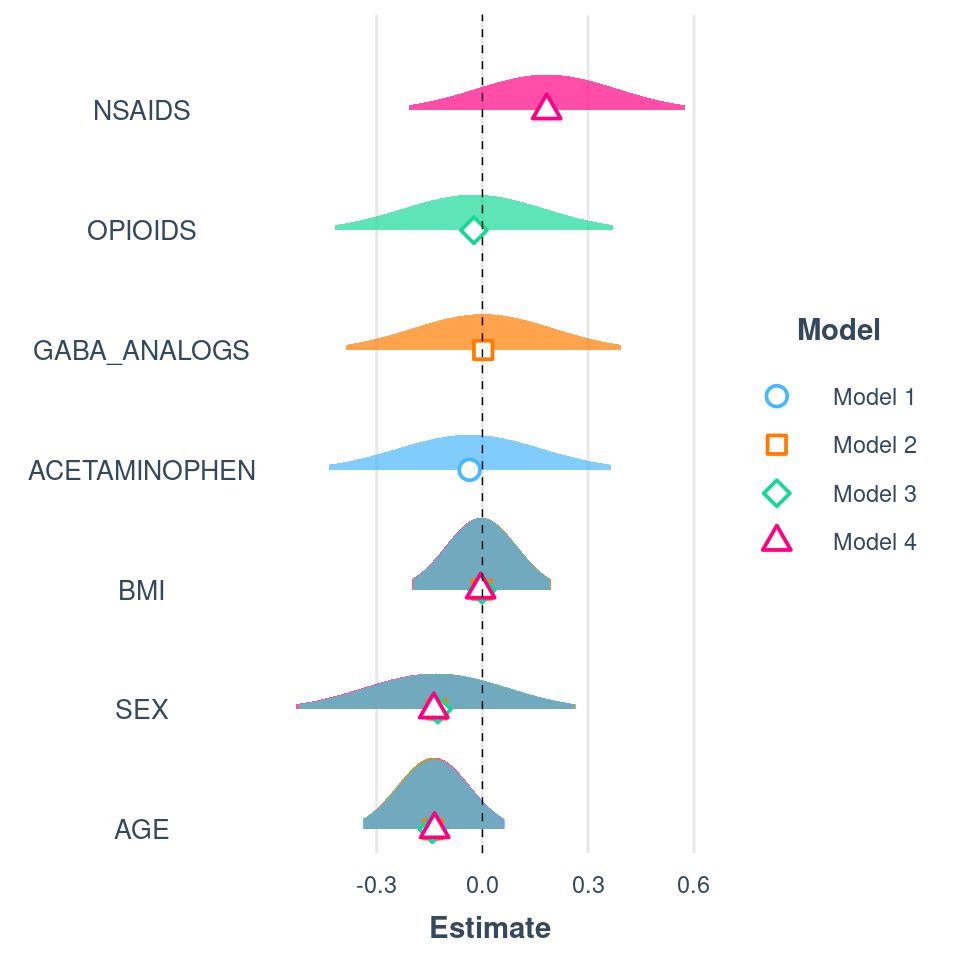

```r
plot_summs(m1ac, m1gb, m1op, m1ns, scale = T, plot.distributions = T)
```

## 3.4 Neuropathic Pain models

### 3.4.1 Dependent variable: Pain change

**PAIN_CHANGE ~ DRUG + AGE + SEX + BMI + (1 | CLINIC)**

```r
dt <- df %>% dplyr::filter(DIAGNOSIS == "Neuropathic Pain")
m1ac <- lmer(PAIN_CHANGE ~ AGE + SEX + BMI + (1 | CLINIC) + ACETAMINOPHEN,
            data = dt)
m1gb <- lmer(PAIN_CHANGE ~ GABA_ANALOGS + AGE + SEX + BMI + (1 | CLINIC),
            data = dt)
m1op <- lmer(PAIN_CHANGE ~ OPIOIDS + AGE + SEX + BMI + (1 | CLINIC),
            data = dt)
m1ns <- lmer(PAIN_CHANGE ~ NSAIDS + AGE + SEX + BMI + (1 | CLINIC),
            data = dt)
export_summs(m1ac, m1gb, m1op, m1ns, scale = TRUE,
             error_format = "[{conf.low}, {conf.high}]")
```

|  | Model 1 | Model 2 | Model 3 | Model 4 |
| --- | --- | --- | --- | --- |
| (Intercept) | -0.72 ** | -0.95 *** | -1.08 *** | -1.03 *** |
|  | [-1.10, -0.35] | [-1.32, -0.57] | [-1.44, -0.72] | [-1.38, -0.67] |
| AGE | 0.15 | 0.13 | 0.14 | 0.13 |
|  | [-0.10, 0.39] | [-0.12, 0.38] | [-0.10, 0.39] | [-0.11, 0.38] |
| SEX | 0.32 | 0.31 | 0.29 | 0.31 |
|  | [-0.20, 0.83] | [-0.22, 0.83] | [-0.23, 0.81] | [-0.21, 0.83] |
| BMI | 0.11 | 0.12 | 0.11 | 0.12 |
|  | [-0.13, 0.36] | [-0.12, 0.37] | [-0.13, 0.36] | [-0.12, 0.37] |
| ACETAMINOPHEN | -0.50 |  |  |  |
|  | [-0.98, -0.01] |  |  |  |
| GABA_ANALOGS |  | -0.02 |  |  |
|  |  | [-0.52, 0.48] |  |  |
| OPIOIDS |  |  | 0.32 |  |
|  |  |  | [-0.18, 0.81] |  |
| NSAIDS |  |  |  | 0.20 |
|  |  |  |  | [-0.31, 0.71] |
| N | 339 | 339 | 339 | 339 |
| N (CLINIC) | 5 | 5 | 5 | 5 |
| AIC | 1540.39 | 1544.27 | 1542.74 | 1543.63 |
| BIC | 1567.17 | 1571.05 | 1569.52 | 1570.41 |
| R2 (fixed) | 0.02 | 0.01 | 0.01 | 0.01 |
| R2 (total) | 0.02 | 0.01 | 0.01 | 0.01 |
| All continuous predictors are mean-centered and scaled by 1 standard deviation. *** p < 0.001; ** p < 0.01; * p < 0.05. |  |  |  |  |

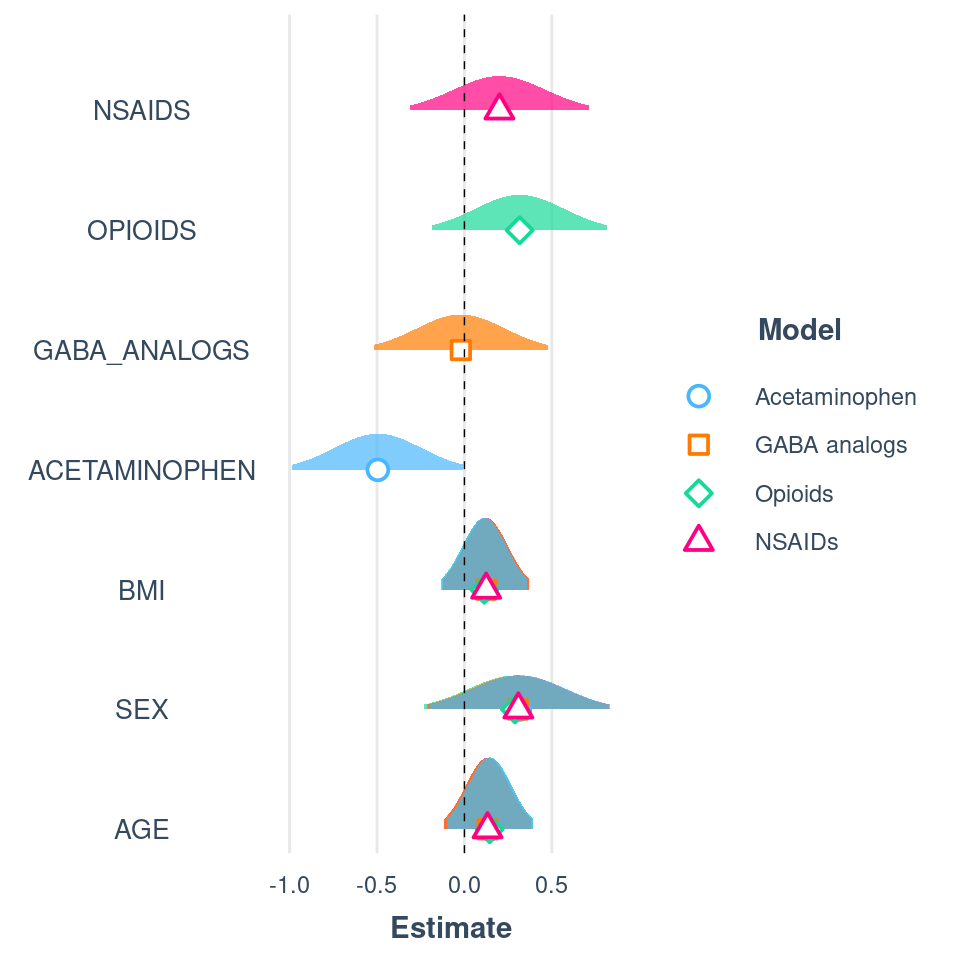

```r
plot_summs(m1ac, m1gb, m1op, m1ns, scale = T, plot.distributions = T,
           model.names = c("Acetaminophen","GABA analogs",
                           "Opioids","NSAIDs"))
```

### 3.4.2 Dependent variable: Pain at follow-up (corrected for baseline pain)

**PAIN_FOLLOW_UP ~ DRUG + AGE + SEX + BMI + PAIN_BASELINE + (1 | CLINIC)**

```r
m1ac <- lmer(PAIN_FOLLOW_UP ~ AGE + SEX + BMI + (1 | CLINIC) + PAIN_BASELINE + ACETAMINOPHEN,
            data = dt)
m1gb <- lmer(PAIN_FOLLOW_UP ~ GABA_ANALOGS + AGE + SEX + BMI + (1 | CLINIC) + PAIN_BASELINE,
            data = dt)
m1op <- lmer(PAIN_FOLLOW_UP ~ OPIOIDS + AGE + SEX + BMI + (1 | CLINIC) + PAIN_BASELINE,
            data = dt)
m1ns <- lmer(PAIN_FOLLOW_UP ~ NSAIDS + AGE + SEX + BMI + (1 | CLINIC) + PAIN_BASELINE,
            data = dt)
export_summs(m1ac, m1gb, m1op, m1ns, scale = TRUE,
             error_format = "[{conf.low}, {conf.high}]")
```

|  | Model 1 | Model 2 | Model 3 | Model 4 |
| --- | --- | --- | --- | --- |
| (Intercept) | 5.84 *** | 5.80 *** | 5.53 *** | 5.64 *** |
|  | [5.50, 6.19] | [5.47, 6.13] | [5.20, 5.85] | [5.32, 5.96] |
| AGE | 0.17 | 0.17 | 0.18 | 0.16 |
|  | [-0.05, 0.39] | [-0.05, 0.40] | [-0.04, 0.41] | [-0.06, 0.39] |
| SEX | 0.23 | 0.23 | 0.20 | 0.23 |
|  | [-0.24, 0.70] | [-0.24, 0.71] | [-0.27, 0.67] | [-0.24, 0.70] |
| BMI | 0.20 | 0.22 | 0.19 | 0.21 |
|  | [-0.02, 0.43] | [-0.01, 0.44] | [-0.03, 0.42] | [-0.01, 0.44] |
| PAIN_BASELINE | 0.90 *** | 0.87 *** | 0.86 *** | 0.88 *** |
|  | [0.67, 1.12] | [0.65, 1.10] | [0.63, 1.08] | [0.65, 1.10] |
| ACETAMINOPHEN | -0.24 |  |  |  |
|  | [-0.69, 0.21] |  |  |  |
| GABA_ANALOGS |  | -0.16 |  |  |
|  |  | [-0.62, 0.29] |  |  |
| OPIOIDS |  |  | 0.51 * |  |
|  |  |  | [0.05, 0.96] |  |
| NSAIDS |  |  |  | 0.26 |
|  |  |  |  | [-0.21, 0.72] |
| N | 339 | 339 | 339 | 339 |
| N (CLINIC) | 5 | 5 | 5 | 5 |
| AIC | 1482.89 | 1483.50 | 1479.22 | 1482.78 |
| BIC | 1513.50 | 1514.11 | 1509.83 | 1513.39 |
| R2 (fixed) | 0.17 | 0.17 | 0.18 | 0.17 |
| R2 (total) | 0.17 | 0.17 | 0.18 | 0.17 |
| All continuous predictors are mean-centered and scaled by 1 standard deviation. *** p < 0.001; ** p < 0.01; * p < 0.05. |  |  |  |  |

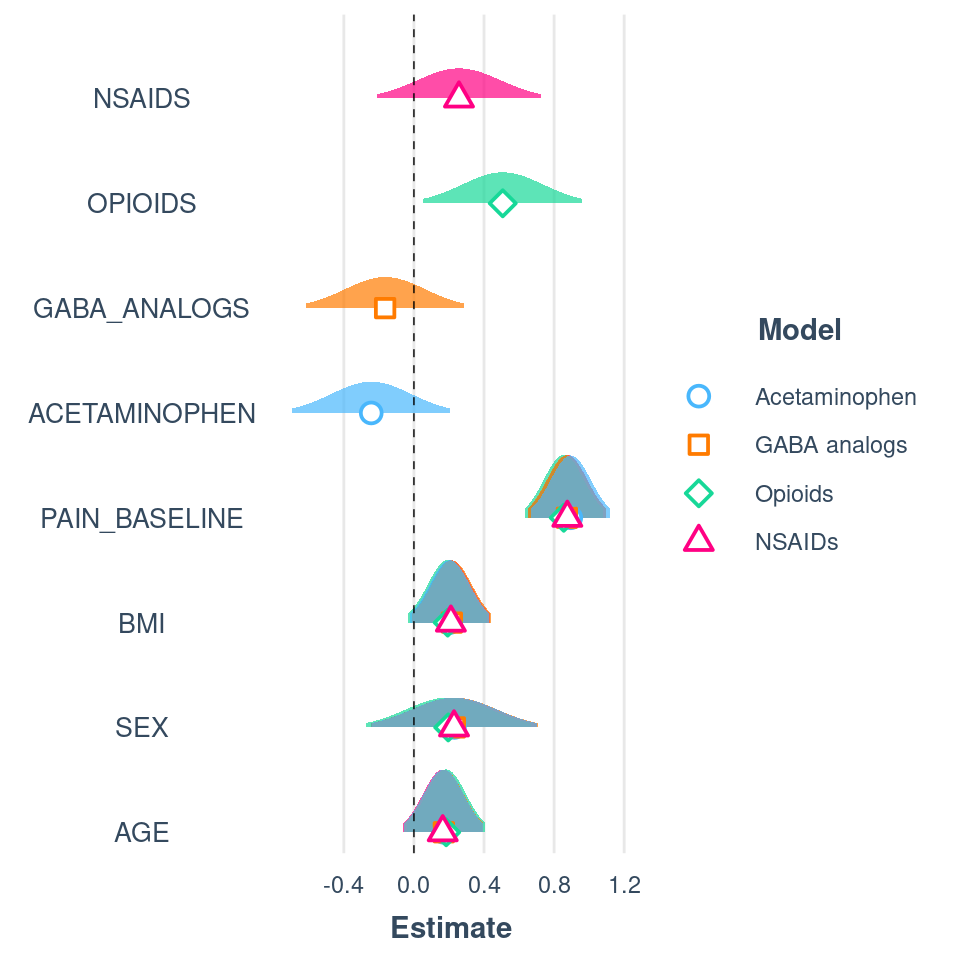

```r
plot_summs(m1ac, m1gb, m1op, m1ns, scale = T, plot.distributions = T,
           model.names = c("Acetaminophen","GABA analogs",
                           "Opioids","NSAIDs"))
```

### 3.4.3 Dependent variable: Pain improved

**PAIN_IMPROVED ~ DRUG + AGE + SEX + BMI + (1 | CLINIC)**

```r
m1ac <- glmer(PAIN_IMPROVED ~ AGE + SEX + BMI + (1 | CLINIC) + ACETAMINOPHEN,
            family = binomial, data = dt)
m1gb <- glmer(PAIN_IMPROVED ~ GABA_ANALOGS + AGE + SEX + BMI + (1 | CLINIC),
            family = binomial, data = dt)
m1op <- glmer(PAIN_IMPROVED ~ OPIOIDS + AGE + SEX + BMI + (1 | CLINIC),
            family = binomial, data = dt)
m1ns <- glmer(PAIN_IMPROVED ~ NSAIDS + AGE + SEX + BMI + (1 | CLINIC),
            family = binomial, data = dt)
export_summs(m1ac, m1gb, m1op, m1ns, scale = TRUE,
             error_format = "[{conf.low}, {conf.high}]")
```

|  | Model 1 | Model 2 | Model 3 | Model 4 |
| --- | --- | --- | --- | --- |
| (Intercept) | 0.20 | 0.18 | 0.25 | 0.21 |
|  | [-0.13, 0.53] | [-0.14, 0.50] | [-0.07, 0.57] | [-0.10, 0.52] |
| AGE | -0.13 | -0.13 | -0.13 | -0.13 |
|  | [-0.35, 0.09] | [-0.35, 0.08] | [-0.35, 0.08] | [-0.35, 0.09] |
| SEX | -0.20 | -0.21 | -0.20 | -0.20 |
|  | [-0.66, 0.25] | [-0.66, 0.25] | [-0.65, 0.26] | [-0.65, 0.25] |
| BMI | -0.09 | -0.09 | -0.09 | -0.09 |
|  | [-0.31, 0.13] | [-0.31, 0.12] | [-0.30, 0.13] | [-0.31, 0.13] |
| ACETAMINOPHEN | 0.04 |  |  |  |
|  | [-0.39, 0.47] |  |  |  |
| GABA_ANALOGS |  | 0.09 |  |  |
|  |  | [-0.34, 0.53] |  |  |
| OPIOIDS |  |  | -0.08 |  |
|  |  |  | [-0.52, 0.35] |  |
| NSAIDS |  |  |  | 0.03 |
|  |  |  |  | [-0.42, 0.48] |
| N | 339 | 339 | 339 | 339 |
| N (CLINIC) | 5 | 5 | 5 | 5 |
| AIC | 477.23 | 477.09 | 477.12 | 477.25 |
| BIC | 500.19 | 500.04 | 500.07 | 500.20 |
| R2 (fixed) | 0.01 | 0.01 | 0.01 | 0.01 |
| R2 (total) | 0.01 | 0.01 | 0.01 | 0.01 |
| All continuous predictors are mean-centered and scaled by 1 standard deviation. *** p < 0.001; ** p < 0.01; * p < 0.05. |  |  |  |  |

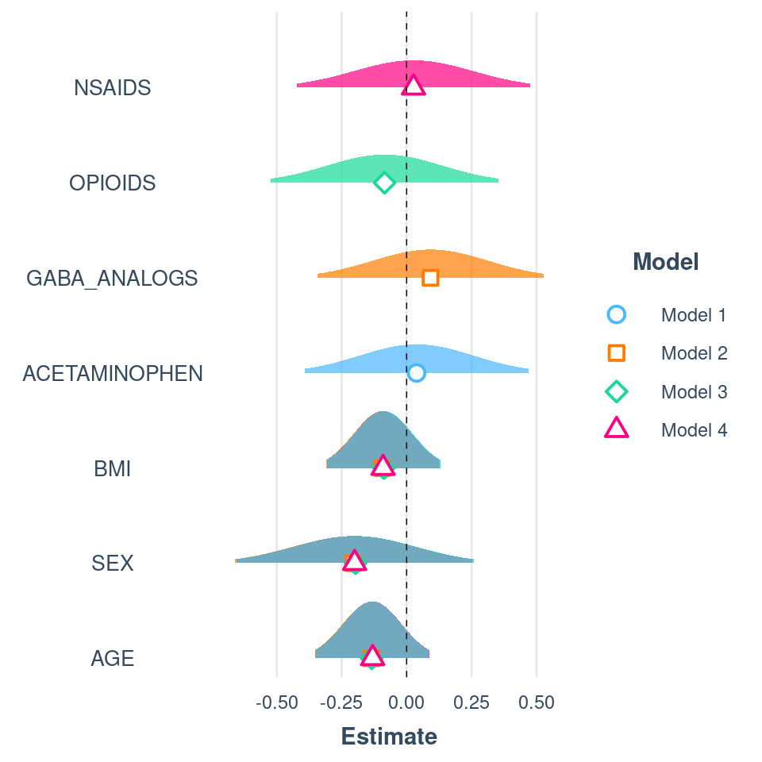

```r
plot_summs(m1ac, m1gb, m1op, m1ns, scale = T, plot.distributions = T)
```

## 3.5 Interaction models

### 3.5.1 Dependent variable: Pain change

**PAIN_CHANGE ~ DRUG * DIAGNOSIS + AGE + SEX + BMI + (1 | CLINIC)**

```r
m1ac <- lmer(PAIN_CHANGE ~ AGE + SEX + BMI + (1 | CLINIC) + ACETAMINOPHEN*DIAGNOSIS,
            data = df)
m1gb <- lmer(PAIN_CHANGE ~ GABA_ANALOGS*DIAGNOSIS + AGE + SEX + BMI + (1 | CLINIC),
            data = df)
m1op <- lmer(PAIN_CHANGE ~ OPIOIDS*DIAGNOSIS + AGE + SEX + BMI + (1 | CLINIC),
            data = df)
m1ns <- lmer(PAIN_CHANGE ~ NSAIDS*DIAGNOSIS + AGE + SEX + BMI + (1 | CLINIC),
            data = df)
export_summs(m1ac, m1gb, m1op, m1ns, scale = TRUE,
             error_format = "[{conf.low}, {conf.high}]")
```

|  | Model 1 | Model 2 | Model 3 | Model 4 |
| --- | --- | --- | --- | --- |
| (Intercept) | -1.18 *** | -0.96 *** | -1.13 *** | -0.96 *** |
|  | [-1.55, -0.80] | [-1.33, -0.60] | [-1.50, -0.77] | [-1.33, -0.60] |
| AGE | 0.11 | 0.11 | 0.12 | 0.11 |
|  | [-0.06, 0.28] | [-0.06, 0.28] | [-0.05, 0.29] | [-0.06, 0.28] |
| SEX | 0.18 | 0.18 | 0.17 | 0.19 |
|  | [-0.16, 0.52] | [-0.16, 0.53] | [-0.18, 0.51] | [-0.16, 0.53] |
| BMI | 0.09 | 0.09 | 0.08 | 0.09 |
|  | [-0.08, 0.25] | [-0.07, 0.26] | [-0.08, 0.25] | [-0.07, 0.26] |
| ACETAMINOPHEN | 0.10 |  |  |  |
|  | [-0.36, 0.56] |  |  |  |
| DIAGNOSIS | 0.51 * | 0.07 | 0.11 | -0.00 |
|  | [0.03, 0.98] | [-0.39, 0.52] | [-0.34, 0.57] | [-0.44, 0.44] |
| ACETAMINOPHEN:DIAGNOSIS | -0.57 |  |  |  |
|  | [-1.25, 0.10] |  |  |  |
| GABA_ANALOGS |  | -0.35 |  |  |
|  |  | [-0.81, 0.10] |  |  |
| GABA_ANALOGS:DIAGNOSIS |  | 0.36 |  |  |
|  |  | [-0.32, 1.03] |  |  |
| OPIOIDS |  |  | 0.03 |  |
|  |  |  | [-0.42, 0.49] |  |
| OPIOIDS:DIAGNOSIS |  |  | 0.28 |  |
|  |  |  | [-0.40, 0.95] |  |
| NSAIDS |  |  |  | -0.35 |
|  |  |  |  | [-0.80, 0.10] |
| NSAIDS:DIAGNOSIS |  |  |  | 0.55 |
|  |  |  |  | [-0.14, 1.24] |
| N | 756 | 756 | 756 | 756 |
| N (CLINIC) | 5 | 5 | 5 | 5 |
| AIC | 3453.04 | 3454.29 | 3455.19 | 3453.68 |
| BIC | 3494.69 | 3495.94 | 3496.84 | 3495.33 |
| R2 (fixed) | 0.01 | 0.01 | 0.01 | 0.01 |
| R2 (total) | 0.01 | 0.01 | 0.01 | 0.01 |
| All continuous predictors are mean-centered and scaled by 1 standard deviation. *** p < 0.001; ** p < 0.01; * p < 0.05. |  |  |  |  |

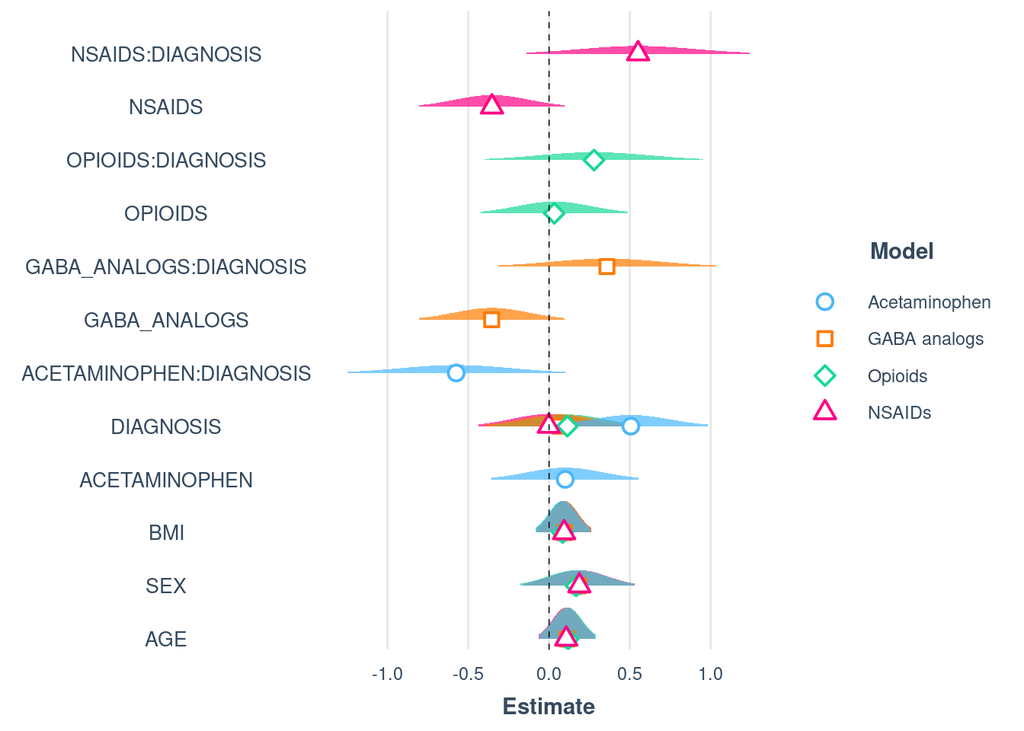

```r
plot_summs(m1ac, m1gb, m1op, m1ns, scale = T, plot.distributions = T,
           model.names = c("Acetaminophen","GABA analogs",
                           "Opioids","NSAIDs"))
```

### 3.5.2 Dependent variable: Pain at follow-up (corrected for baseline pain)

**PAIN_FOLLOW_UP ~ DRUG * DIAGNOSIS + AGE + SEX + BMI + PAIN_BASELINE + (1 | CLINIC)**

```r
m1ac <- lmer(PAIN_FOLLOW_UP ~ AGE + SEX + BMI + (1 | CLINIC) + PAIN_BASELINE + ACETAMINOPHEN*DIAGNOSIS,
            data = df)
m1gb <- lmer(PAIN_FOLLOW_UP ~ GABA_ANALOGS*DIAGNOSIS + AGE + SEX + BMI + (1 | CLINIC) + PAIN_BASELINE,
            data = df)
m1op <- lmer(PAIN_FOLLOW_UP ~ OPIOIDS*DIAGNOSIS + AGE + SEX + BMI + (1 | CLINIC) + PAIN_BASELINE,
            data = df)
m1ns <- lmer(PAIN_FOLLOW_UP ~ NSAIDS*DIAGNOSIS + AGE + SEX + BMI + (1 | CLINIC) + PAIN_BASELINE,
            data = df)
export_summs(m1ac, m1gb, m1op, m1ns, scale = TRUE,
             error_format = "[{conf.low}, {conf.high}]")
```

|  | Model 1 | Model 2 | Model 3 | Model 4 |
| --- | --- | --- | --- | --- |
| (Intercept) | 5.51 *** | 5.75 *** | 5.51 *** | 5.77 *** |
|  | [5.17, 5.84] | [5.43, 6.07] | [5.20, 5.81] | [5.45, 6.08] |
| AGE | 0.16 * | 0.17 * | 0.18 * | 0.16 * |
|  | [0.00, 0.31] | [0.02, 0.32] | [0.03, 0.33] | [0.01, 0.31] |
| SEX | 0.05 | 0.06 | 0.02 | 0.06 |
|  | [-0.26, 0.36] | [-0.25, 0.37] | [-0.29, 0.33] | [-0.25, 0.37] |
| BMI | 0.20 * | 0.20 ** | 0.19 * | 0.20 * |
|  | [0.04, 0.35] | [0.05, 0.35] | [0.03, 0.34] | [0.05, 0.35] |
| PAIN_BASELINE | 0.84 *** | 0.83 *** | 0.82 *** | 0.83 *** |
|  | [0.69, 0.99] | [0.68, 0.99] | [0.67, 0.97] | [0.68, 0.99] |
| ACETAMINOPHEN | 0.18 |  |  |  |
|  | [-0.24, 0.59] |  |  |  |
| DIAGNOSIS | 0.41 | 0.13 | 0.11 | -0.04 |
|  | [-0.02, 0.84] | [-0.28, 0.55] | [-0.30, 0.51] | [-0.43, 0.35] |
| ACETAMINOPHEN:DIAGNOSIS | -0.39 |  |  |  |
|  | [-1.00, 0.22] |  |  |  |
| GABA_ANALOGS |  | -0.35 |  |  |
|  |  | [-0.75, 0.06] |  |  |
| GABA_ANALOGS:DIAGNOSIS |  | 0.19 |  |  |
|  |  | [-0.42, 0.80] |  |  |
| OPIOIDS |  |  | 0.22 |  |
|  |  |  | [-0.19, 0.63] |  |
| OPIOIDS:DIAGNOSIS |  |  | 0.30 |  |
|  |  |  | [-0.30, 0.91] |  |
| NSAIDS |  |  |  | -0.37 |
|  |  |  |  | [-0.78, 0.03] |
| NSAIDS:DIAGNOSIS |  |  |  | 0.63 * |
|  |  |  |  | [0.01, 1.25] |
| N | 756 | 756 | 756 | 756 |
| N (CLINIC) | 5 | 5 | 5 | 5 |
| AIC | 3302.26 | 3300.60 | 3297.82 | 3299.37 |
| BIC | 3348.54 | 3346.88 | 3344.10 | 3345.65 |
| R2 (fixed) | 0.16 | 0.16 | 0.16 | 0.16 |
| R2 (total) | 0.16 | 0.16 | 0.16 | 0.16 |
| All continuous predictors are mean-centered and scaled by 1 standard deviation. *** p < 0.001; ** p < 0.01; * p < 0.05. |  |  |  |  |

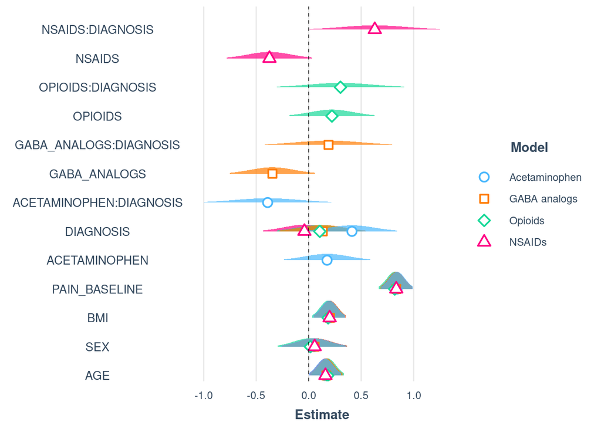

```r
plot_summs(m1ac, m1gb, m1op, m1ns, scale = T, plot.distributions = T,
           model.names = c("Acetaminophen","GABA analogs",
                           "Opioids","NSAIDs"))
```

### 3.5.3 Dependent variable: Pain improved

**PAIN_IMPROVED ~ DRUG * DIAGNOSIS + AGE + SEX + BMI + (1 | CLINIC)**

```r
m1ac <- glmer(PAIN_IMPROVED ~ AGE + SEX + BMI + (1 | CLINIC) + ACETAMINOPHEN*DIAGNOSIS,
            family = binomial, data = df)
m1gb <- glmer(PAIN_IMPROVED ~ GABA_ANALOGS*DIAGNOSIS + AGE + SEX + BMI + (1 | CLINIC),
            family = binomial, data = df)
m1op <- glmer(PAIN_IMPROVED ~ OPIOIDS*DIAGNOSIS + AGE + SEX + BMI + (1 | CLINIC),
            family = binomial, data = df)
m1ns <- glmer(PAIN_IMPROVED ~ NSAIDS*DIAGNOSIS + AGE + SEX + BMI + (1 | CLINIC),
            family = binomial, data = df)
export_summs(m1ac, m1gb, m1op, m1ns, scale = TRUE,
             error_format = "[{conf.low}, {conf.high}]")
```

|  | Model 1 | Model 2 | Model 3 | Model 4 |
| --- | --- | --- | --- | --- |
| (Intercept) | 0.35 * | 0.33 * | 0.33 * | 0.24 |
|  | [0.04, 0.67] | [0.03, 0.62] | [0.04, 0.63] | [-0.05, 0.54] |
| AGE | -0.13 | -0.14 | -0.14 | -0.13 |
|  | [-0.28, 0.01] | [-0.29, 0.01] | [-0.29, 0.01] | [-0.28, 0.01] |
| SEX | -0.16 | -0.16 | -0.15 | -0.16 |
|  | [-0.45, 0.14] | [-0.46, 0.14] | [-0.45, 0.14] | [-0.46, 0.13] |
| BMI | -0.04 | -0.04 | -0.04 | -0.04 |
|  | [-0.19, 0.10] | [-0.19, 0.10] | [-0.19, 0.10] | [-0.19, 0.10] |
| ACETAMINOPHEN | -0.05 |  |  |  |
|  | [-0.44, 0.35] |  |  |  |
| DIAGNOSIS | -0.19 | -0.18 | -0.11 | -0.07 |
|  | [-0.60, 0.22] | [-0.58, 0.21] | [-0.51, 0.28] | [-0.45, 0.30] |
| ACETAMINOPHEN:DIAGNOSIS | 0.09 |  |  |  |
|  | [-0.49, 0.67] |  |  |  |
| GABA_ANALOGS |  | 0.01 |  |  |
|  |  | [-0.38, 0.40] |  |  |
| GABA_ANALOGS:DIAGNOSIS |  | 0.08 |  |  |
|  |  | [-0.50, 0.66] |  |  |
| OPIOIDS |  |  | -0.01 |  |
|  |  |  | [-0.41, 0.38] |  |
| OPIOIDS:DIAGNOSIS |  |  | -0.08 |  |
|  |  |  | [-0.66, 0.50] |  |
| NSAIDS |  |  |  | 0.19 |
|  |  |  |  | [-0.20, 0.58] |
| NSAIDS:DIAGNOSIS |  |  |  | -0.16 |
|  |  |  |  | [-0.76, 0.44] |
| N | 756 | 756 | 756 | 756 |
| N (CLINIC) | 5 | 5 | 5 | 5 |
| AIC | 1051.54 | 1051.48 | 1051.44 | 1050.73 |
| BIC | 1088.56 | 1088.51 | 1088.46 | 1087.75 |
| R2 (fixed) | 0.01 | 0.01 | 0.01 | 0.01 |
| R2 (total) | 0.01 | 0.01 | 0.01 | 0.01 |
| All continuous predictors are mean-centered and scaled by 1 standard deviation. *** p < 0.001; ** p < 0.01; * p < 0.05. |  |  |  |  |

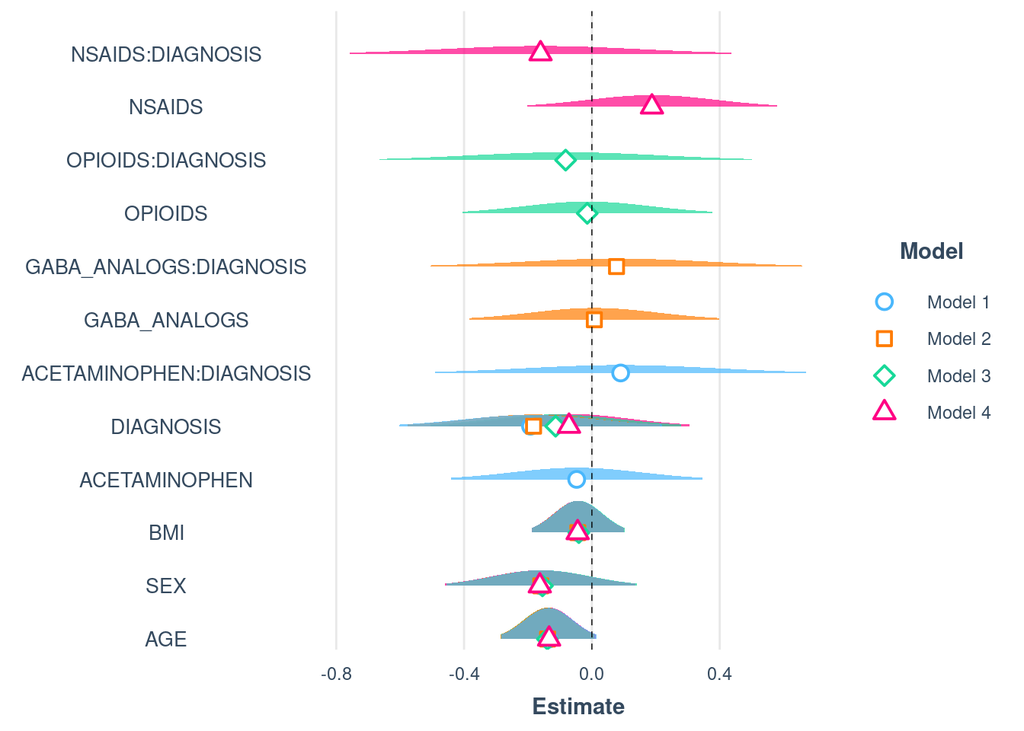

```r
plot_summs(m1ac, m1gb, m1op, m1ns, scale = T, plot.distributions = T)
```

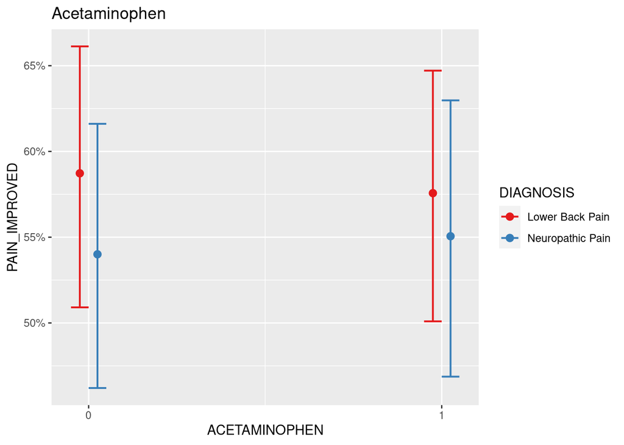

```r
m1ac <- glmer(as.factor(PAIN_IMPROVED) ~ AGE + SEX + BMI + (1 | CLINIC) + ACETAMINOPHEN*DIAGNOSIS,
            family = binomial, data = df)
m1gb <- glmer(as.factor(PAIN_IMPROVED) ~ GABA_ANALOGS*DIAGNOSIS + AGE + SEX + BMI + (1 | CLINIC),
            family = binomial, data = df)
m1op <- glmer(as.factor(PAIN_IMPROVED) ~ OPIOIDS*DIAGNOSIS + AGE + SEX + BMI + (1 | CLINIC),
            family = binomial, data = df)
m1ns <- glmer(as.factor(PAIN_IMPROVED) ~ NSAIDS*DIAGNOSIS + AGE + SEX + BMI + (1 | CLINIC),
            family = binomial, data = df)
plot_model(m1ac,type = "int", title = "Acetaminophen")
```

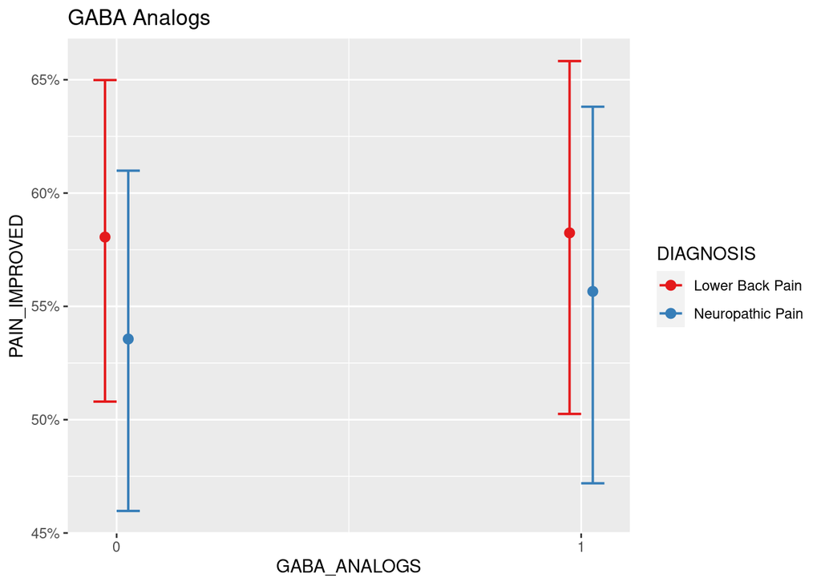

```r
plot_model(m1gb,type = "int", title = "GABA Analogs")
```

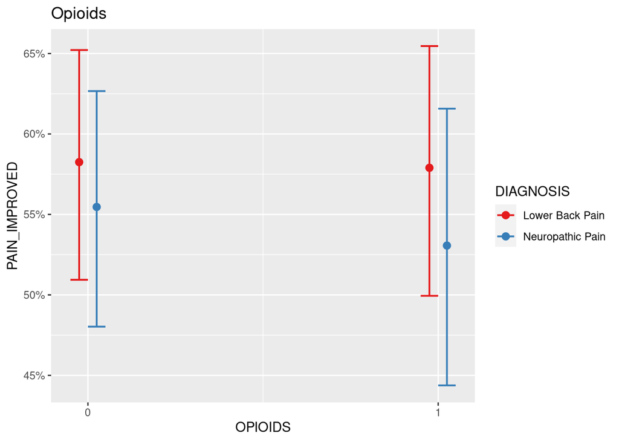

```r
plot_model(m1op,type = "int", title = "Opioids")
```

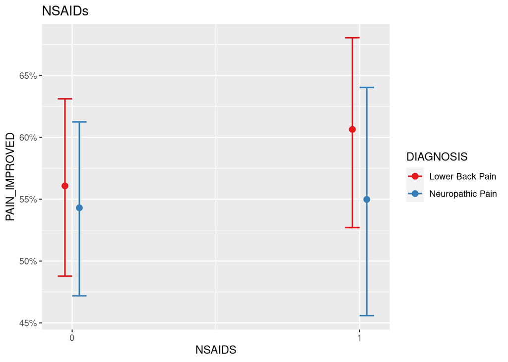

```r
plot_model(m1ns,type = "int", title = "NSAIDs")
```